# Prediction SARS CoV-2 using regression

Shrey

5/31/2020

## Disease Dataset Analysis

importing dataset and summarize the disease dataset. Skipping first column as it is just the ID column

```r
# Summarizing disease dataset
summary(disease)
```

```
##  Patient age quantile SARS-Cov-2 exam result Respiratory Syncytial Virus
##  Min.   : 0.000       Min.   :0.00000        Min.   :0.00000
##  1st Qu.: 3.000       1st Qu.:0.00000        1st Qu.:0.00000
##  Median : 9.000       Median :0.00000        Median :0.00000
##  Mean   : 9.141       Mean   :0.08284        Mean   :0.03846
##  3rd Qu.:14.000       3rd Qu.:0.00000        3rd Qu.:0.00000
##  Max.   :19.000       Max.   :1.00000        Max.   :1.00000
##   Influenza B       Influenza A      Coronavirus HKU1  Parainfluenza 1
##  Min.   :0.00000   Min.   :0.00000   Min.   :0.00000   Min.   :0.000000
##  1st Qu.:0.00000   1st Qu.:0.00000   1st Qu.:0.00000   1st Qu.:0.000000
##  Median :0.00000   Median :0.00000   Median :0.00000   Median :0.000000
##  Mean   :0.05621   Mean   :0.01331   Mean   :0.01479   Mean   :0.002219
##  3rd Qu.:0.00000   3rd Qu.:0.00000   3rd Qu.:0.00000   3rd Qu.:0.000000
##  Max.   :1.00000   Max.   :1.00000   Max.   :1.00000   Max.   :1.000000
##  Parainfluenza 2 Metapneumovirus   Bordetella pertussis Inf A H1N1 2009
##  Min.   :0       Min.   :0.00000   Min.   :0.000000     Min.   :0.00000
##  1st Qu.:0       1st Qu.:0.00000   1st Qu.:0.000000     1st Qu.:0.00000
##  Median :0       Median :0.00000   Median :0.000000     Median :0.00000
##  Mean   :0       Mean   :0.01035   Mean   :0.001479     Mean   :0.07249
##  3rd Qu.:0       3rd Qu.:0.00000   3rd Qu.:0.000000     3rd Qu.:0.00000
##  Max.   :0       Max.   :1.00000   Max.   :1.000000     Max.   :1.00000
##  CoronavirusOC43    Coronavirus229E    Parainfluenza 4     Adenovirus
##  Min.   :0.000000   Min.   :0.000000   Min.   :0.00000   Min.   :0.000000
##  1st Qu.:0.000000   1st Qu.:0.000000   1st Qu.:0.00000   1st Qu.:0.000000
##  Median :0.000000   Median :0.000000   Median :0.00000   Median :0.000000
##  Mean   :0.005917   Mean   :0.006657   Mean   :0.01405   Mean   :0.009615
##  3rd Qu.:0.000000   3rd Qu.:0.000000   3rd Qu.:0.00000   3rd Qu.:0.000000
##  Max.   :1.000000   Max.   :1.000000   Max.   :1.00000   Max.   :1.000000
##  Chlamydophila pneumoniae Parainfluenza 3    Rhinovirus/Enterovirus
##  Min.   :0.000000         Min.   :0.000000   Min.   :0.0000
##  1st Qu.:0.000000         1st Qu.:0.000000   1st Qu.:0.0000
##  Median :0.000000         Median :0.000000   Median :0.0000
##  Mean   :0.006657         Mean   :0.007396   Mean   :0.2803
##  3rd Qu.:0.000000         3rd Qu.:0.000000   3rd Qu.:1.0000
##  Max.   :1.000000         Max.   :1.000000   Max.   :1.0000
##  CoronavirusNL63
##  Min.   :0.00000
##  1st Qu.:0.00000
##  Median :0.00000
##  Mean   :0.03328
##  3rd Qu.:0.00000
##  Max.   :1.00000
```

We have to skip Parainfluenza 2 as it contains only zeros. Also renming all the columns.

### Plotting CramerV’s correlation for the catagorical variables.

```r
# CramerV Correlation to check for any correlation between catagorical variables
# Except Patient's age, all other variables are catagorical(binary)
disease.corr = PairApply(disease[,names(disease) != "Patient_Age_Quantile"],cramerV, symmetric = TRUE)
# Displaying correlation with variable SARS_COV2_Result
disease.corr[,2]
```

```
##            SARS_COV2_Result Respiratory_Syncytial_Virus
##                    0.060110                    1.000000
##                 Influenza_B                 Influenza_A
##                    0.048810                    0.023230
##            Coronavirus_HKU1             Parainfluenza_1
##                    0.007352                    0.009432
##             Metapneumovirus        Bordetella_pertussis
##                    0.020460                    0.007698
##             Inf_A_H1N1_2009             CoronavirusOC43
##                    0.055910                    0.015430
##             Coronavirus229E             Parainfluenza_4
##                    0.016370                    0.008797
##                  Adenovirus    Chlamydophila_pneumoniae
##                    0.059120                    0.016370
##             Parainfluenza_3   Rhinovirus_OR_Enterovirus
##                    0.017260                    0.013500
##             CoronavirusNL63
##                    0.037110
```

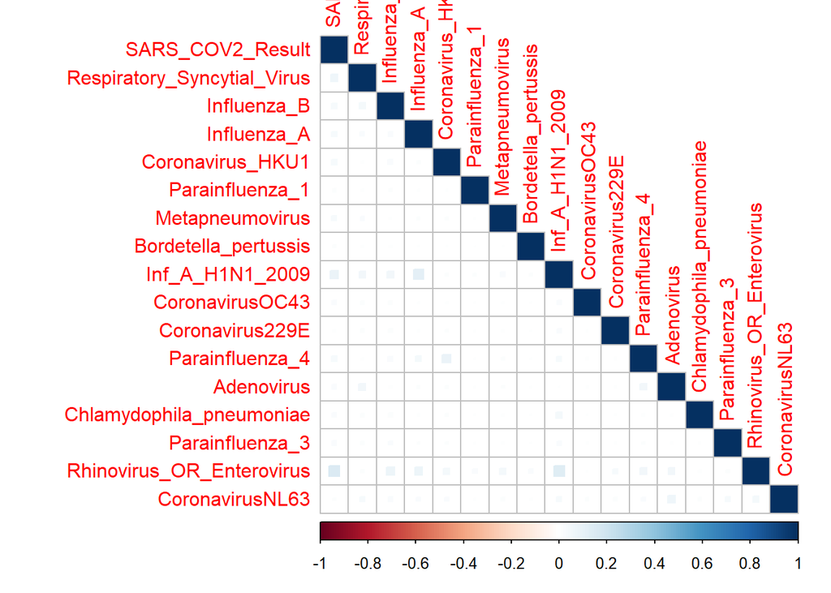

```r
# Correlation plot
corrplot(disease.corr, method = "square", type = "lower")
```

We are now dividing test and training data with 20% and 80% respectively.

Logistic regression analysis on the target variable SARS CoV-2 result with rest of the variables as predictors.

```r
# Summarizing the analysis
summary(disease.glm)
```

```
##
## Call:
## glm(formula = as.formula(disease.function), family = binomial,
##     data = disease.train)
##
## Deviance Residuals:
##      Min        1Q    Median        3Q       Max
## -0.72591  -0.52911  -0.26856  -0.00014   2.97594
##
## Coefficients:
##                               Estimate Std. Error z value Pr(>|z|)
## (Intercept)                 -2.522e+00  2.811e-01  -8.973  < 2e-16 ***
## Patient_Age_Quantile         6.963e-02  2.145e-02   3.246  0.00117 **
## Respiratory_Syncytial_Virus -1.675e+01  1.665e+03  -0.010  0.99197
## Influenza_B                 -9.216e-01  6.110e-01  -1.508  0.13146
## Influenza_A                 -1.698e+01  2.668e+03  -0.006  0.99492
## Coronavirus_HKU1            -1.754e+01  2.431e+03  -0.007  0.99424
## Parainfluenza_1             -1.794e+01  6.187e+03  -0.003  0.99769
## Metapneumovirus             -1.750e+01  2.774e+03  -0.006  0.99497
## Bordetella_pertussis        -1.733e+01  7.594e+03  -0.002  0.99818
## Inf_A_H1N1_2009             -1.737e+01  1.200e+03  -0.014  0.98845
## CoronavirusOC43             -1.740e+01  3.658e+03  -0.005  0.99621
## Coronavirus229E              1.857e-03  1.096e+00   0.002  0.99865
## Parainfluenza_4             -1.666e+01  2.487e+03  -0.007  0.99466
## Adenovirus                  -1.576e+01  2.711e+03  -0.006  0.99536
## Chlamydophila_pneumoniae    -1.722e+01  3.393e+03  -0.005  0.99595
## Parainfluenza_3             -1.759e+01  3.926e+03  -0.004  0.99643
## Rhinovirus_OR_Enterovirus   -2.103e+00  4.682e-01  -4.492 7.07e-06 ***
## CoronavirusNL63             -8.457e-01  7.483e-01  -1.130  0.25843
## ---
## Signif. codes:  0 '***' 0.001 '**' 0.01 '*' 0.05 '.' 0.1 ' ' 1
##
## (Dispersion parameter for binomial family taken to be 1)
##
##     Null deviance: 619.74  on 1080  degrees of freedom
## Residual deviance: 529.48  on 1063  degrees of freedom
## AIC: 565.48
##
## Number of Fisher Scoring iterations: 18
```

We have to reduce dimensions as we do not want unnecessary predictors.

```r
summary(disease.glm)
```

```
##
## Call:
## glm(formula = as.formula(disease.function), family = binomial,
##     data = disease.train)
##
## Deviance Residuals:
##     Min       1Q   Median       3Q      Max
## -0.6621  -0.5052  -0.3520  -0.1938   3.0485
##
## Coefficients:
##                           Estimate Std. Error z value Pr(>|z|)
## (Intercept)               -3.00195    0.26295 -11.416  < 2e-16 ***
## Patient_Age_Quantile       0.08398    0.02019   4.160 3.18e-05 ***
## Rhinovirus_OR_Enterovirus -1.88689    0.46671  -4.043 5.28e-05 ***
## ---
## Signif. codes:  0 '***' 0.001 '**' 0.01 '*' 0.05 '.' 0.1 ' ' 1
##
## (Dispersion parameter for binomial family taken to be 1)
##
##     Null deviance: 619.74  on 1080  degrees of freedom
## Residual deviance: 570.80  on 1078  degrees of freedom
## AIC: 576.8
##
## Number of Fisher Scoring iterations: 6
```

10-fold cross-validation to validate the data

```r
# 10 fold cross-validation to verify the model
 cv.glm(disease.train,disease.glm,K=10)$delta[1]
```

```
## [1] 0.07338679
```

Predicting values in test dataset, confusion matrix and type II error. We are ploting ROC Curve to see how the model is performing.

```r
# Predicting on test data based on training set
disease.glm.predict <- predict(disease.glm,disease.test,type = "response")
summary(disease.glm.predict)
```

```
##     Min.  1st Qu.   Median     Mean  3rd Qu.     Max.
## 0.007474 0.023819 0.070302 0.081027 0.128954 0.196808
```

```r
# Mean predict results for SARS Cov2 Results diagnosis
tapply(disease.glm.predict, disease.test$SARS_COV2_Result, mean)
```

```
##          0          1
## 0.07698771 0.12674909
```

```r
# Confusion matrix for threshold of 1%
disease.confusion = table(disease.test$SARS_COV2_Result, disease.glm.predict > 0.01)
disease.confusion
```

```
##
##     FALSE TRUE
##   0    31  218
##   1     0   22
```

```r
# False negative error rate (Type II error)
disease.type2error = disease.confusion[1,1]/(disease.confusion[1,1]+disease.confusion[2,2])
disease.type2error
```

```
## [1] 0.5849057
```

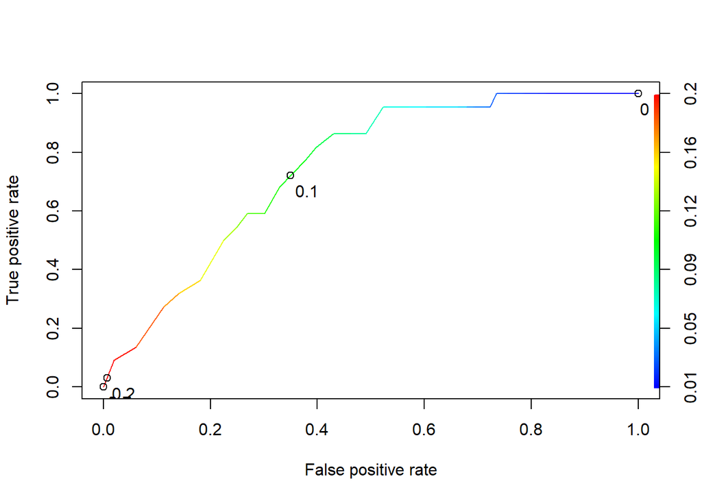

```r
# Plotting ROCR curve
disease.ROCRpred = prediction(disease.glm.predict, disease.test$SARS_COV2_Result)
disease.ROCRperf = performance(disease.ROCRpred, "tpr", "fpr")
plot(disease.ROCRperf, colorize=TRUE, print.cutoffs.at=seq(0,1,by=0.1), text.adj=c(-0.2,1.7))
```

Plotting the probability of having SARS CoV-2 vs Rhinovirus

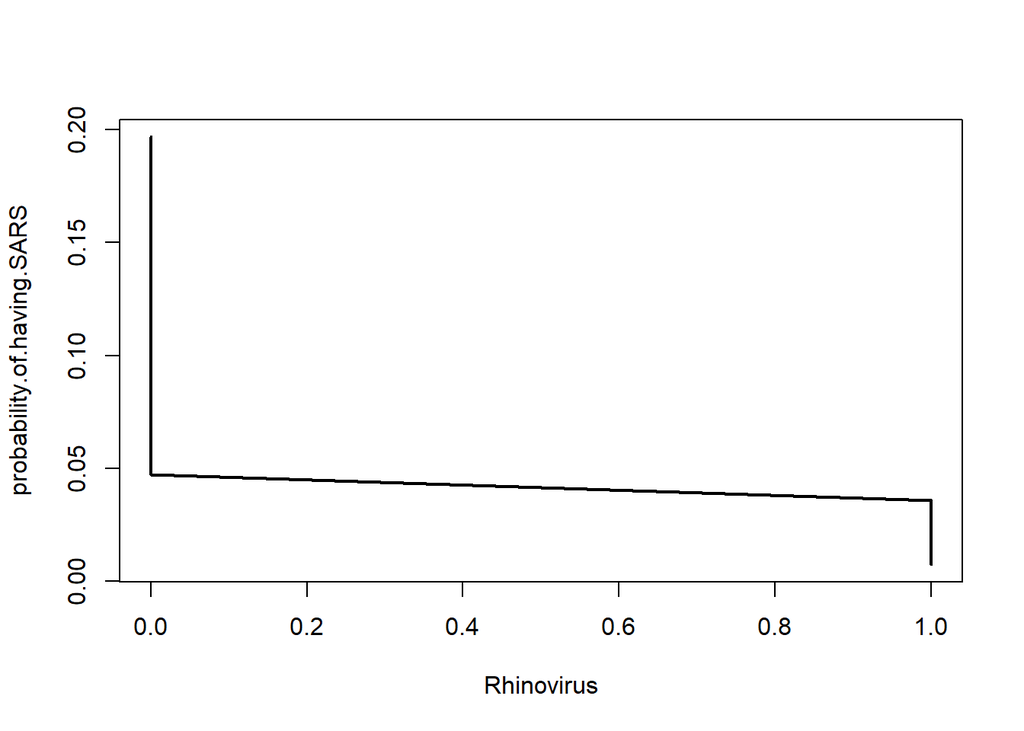

```r
plot(probability.of.having.SARS ~ Rhinovirus,disease.predicted.data, type = "l", lwd = 2)
```

## Condition Dataset Analysis

Importing the dataset and then renaming the columns.

```r
# Summarizing disease dataset
summary(condition)
```

```
##  Patient_Age_Quantile SARS_COV2_Result   Hematocrit          Hemoglobin
##  Min.   : 0.00        Min.   :0.0000   Min.   :-4.501420   Min.   :-4.34560
##  1st Qu.: 7.00        1st Qu.:0.0000   1st Qu.:-0.518807   1st Qu.:-0.58624
##  Median :12.00        Median :0.0000   Median : 0.053407   Median : 0.04032
##  Mean   :11.16        Mean   :0.1379   Mean   :-0.001267   Mean   :-0.00090
##  3rd Qu.:16.00        3rd Qu.:0.0000   3rd Qu.: 0.717175   3rd Qu.: 0.72953
##  Max.   :19.00        Max.   :1.0000   Max.   : 2.662704   Max.   : 2.67187
##  Mean_corpuscular_hemoglobin_MCH Red_blood_cells     Lymphocytes
##  Min.   :-5.9376                 Min.   :-3.97061   Min.   :-1.86507
##  1st Qu.:-0.5014                 1st Qu.:-0.56795   1st Qu.:-0.73071
##  Median : 0.1259                 Median : 0.01385   Median :-0.01427
##  Mean   : 0.0000                 Mean   : 0.00000   Mean   : 0.00000
##  3rd Qu.: 0.5963                 3rd Qu.: 0.66618   3rd Qu.: 0.59769
##  Max.   : 4.0985                 Max.   : 3.64571   Max.   : 3.76410
##    Basophils         Leukocytes       Eosinophils
##  Min.   :-1.1401   Min.   :-2.0203   Min.   :-0.8355
##  1st Qu.:-0.5292   1st Qu.:-0.6373   1st Qu.:-0.6670
##  Median :-0.2238   Median :-0.2129   Median :-0.3298
##  Mean   : 0.0000   Mean   : 0.0000   Mean   : 0.0000
##  3rd Qu.: 0.3872   3rd Qu.: 0.4543   3rd Qu.: 0.3444
##  Max.   :11.0782   Max.   : 4.5220   Max.   : 8.3509
##  Mean_corpuscular_volume_MCV Red_blood_cell_distribution_width_RDW
##  Min.   :-5.10158            Min.   :-1.5981
##  1st Qu.:-0.51481            1st Qu.:-0.6251
##  Median : 0.06605            Median :-0.1828
##  Mean   : 0.00000            Mean   : 0.0000
##  3rd Qu.: 0.62687            3rd Qu.: 0.3479
##  Max.   : 3.41098            Max.   : 6.9822
##    Platelets         Monocytes
##  Min.   :-2.5524   Min.   :-2.16372
##  1st Qu.:-0.6053   1st Qu.:-0.61419
##  Median :-0.1217   Median :-0.11519
##  Mean   : 0.0000   Mean   :-0.00102
##  3rd Qu.: 0.5315   3rd Qu.: 0.48886
##  Max.   : 9.5320   Max.   : 4.53340
##  Mean_corpuscular_hemoglobin_concentration_MCHC Mean_platelet_volume
##  Min.   :-5.43181                               Min.   :-2.457575
##  1st Qu.:-0.55248                               1st Qu.:-0.662483
##  Median :-0.05459                               Median :-0.101517
##  Mean   : 0.00000                               Mean   : 0.000911
##  3rd Qu.: 0.64246                               3rd Qu.: 0.683835
##  Max.   : 3.33107                               Max.   : 3.713052
##   Neutrophils       Proteina_C_reativa_mg_dL
##  Min.   :-3.33977   Min.   :-0.53536
##  1st Qu.:-0.60270   1st Qu.:-0.50754
##  Median : 0.04060   Median :-0.38137
##  Mean   : 0.06185   Mean   :-0.03024
##  3rd Qu.: 0.73101   3rd Qu.: 0.02925
##  Max.   : 2.53593   Max.   : 8.02667
```

Plotting the correlation between numeric variables.

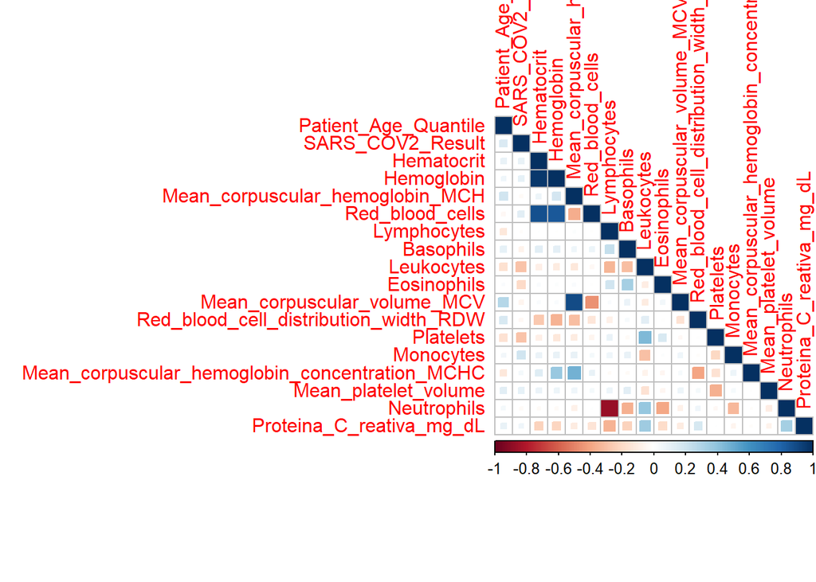

```r
# Correlation plot
corrplot(condition.corr, method = "square", type = "lower")
```

We are now dividing test and training data with 20% and 80% respectively.

Logistic regression analysis on the target variable SARS CoV-2 result with rest of the variables as predictors.

```r
# Summarizing the analysis
summary(condition.glm)
```

```
##
## Call:
## glm(formula = as.formula(condition.function), family = binomial,
##     data = condition.train)
##
## Deviance Residuals:
##     Min       1Q   Median       3Q      Max
## -2.1320  -0.4128  -0.2005  -0.0708   3.8410
##
## Coefficients:
##                                                Estimate Std. Error z value
## (Intercept)                                    -4.33147    0.56621  -7.650
## Patient_Age_Quantile                            0.11080    0.03803   2.914
## Hematocrit                                      5.92756    6.78148   0.874
## Hemoglobin                                     -7.18548    6.31951  -1.137
## Mean_corpuscular_hemoglobin_MCH                -5.73439    5.11206  -1.122
## Red_blood_cells                                 1.57893    2.64780   0.596
## Lymphocytes                                    -1.13814    0.65227  -1.745
## Basophils                                      -0.47308    0.26487  -1.786
## Leukocytes                                     -1.37019    0.33973  -4.033
## Eosinophils                                    -1.29906    0.39276  -3.308
## Mean_corpuscular_volume_MCV                     5.47747    4.68063   1.170
## Red_blood_cell_distribution_width_RDW          -0.34368    0.25689  -1.338
## Platelets                                      -0.47671    0.30328  -1.572
## Monocytes                                      -0.03421    0.23077  -0.148
## Mean_corpuscular_hemoglobin_concentration_MCHC  4.27369    3.05436   1.399
## Mean_platelet_volume                            0.09186    0.19035   0.483
## Neutrophils                                    -1.33231    0.70928  -1.878
## Proteina_C_reativa_mg_dL                        0.65176    0.23502   2.773
##                                                Pr(>|z|)
## (Intercept)                                    2.01e-14 ***
## Patient_Age_Quantile                           0.003570 **
## Hematocrit                                     0.382074
## Hemoglobin                                     0.255525
## Mean_corpuscular_hemoglobin_MCH                0.261974
## Red_blood_cells                                0.550965
## Lymphocytes                                    0.081004 .
## Basophils                                      0.074087 .
## Leukocytes                                     5.50e-05 ***
## Eosinophils                                    0.000941 ***
## Mean_corpuscular_volume_MCV                    0.241904
## Red_blood_cell_distribution_width_RDW          0.180942
## Platelets                                      0.115988
## Monocytes                                      0.882158
## Mean_corpuscular_hemoglobin_concentration_MCHC 0.161751
## Mean_platelet_volume                           0.629382
## Neutrophils                                    0.060328 .
## Proteina_C_reativa_mg_dL                       0.005551 **
## ---
## Signif. codes:  0 '***' 0.001 '**' 0.01 '*' 0.05 '.' 0.1 ' ' 1
##
## (Dispersion parameter for binomial family taken to be 1)
##
##     Null deviance: 380.98  on 480  degrees of freedom
## Residual deviance: 240.88  on 463  degrees of freedom
## AIC: 276.88
##
## Number of Fisher Scoring iterations: 7
```

We have to reduce dimensions as we do not want unnecessary predictors.

```r
summary(condition.glm)
```

```
##
## Call:
## glm(formula = as.formula(condition.function), family = binomial,
##     data = condition.train)
##
## Deviance Residuals:
##     Min       1Q   Median       3Q      Max
## -2.2368  -0.4698  -0.2531  -0.0960   3.6531
##
## Coefficients:
##                                       Estimate Std. Error z value Pr(>|z|)
## (Intercept)                           -3.95550    0.50428  -7.844 4.37e-15 ***
## Patient_Age_Quantile                   0.09294    0.03251   2.859 0.004246 **
## Leukocytes                            -1.10149    0.26864  -4.100 4.13e-05 ***
## Eosinophils                           -1.31165    0.37031  -3.542 0.000397 ***
## Red_blood_cell_distribution_width_RDW -0.40658    0.16967  -2.396 0.016565 *
## Platelets                             -0.64535    0.24349  -2.650 0.008041 **
## Proteina_C_reativa_mg_dL               0.39363    0.20855   1.887 0.059096 .
## ---
## Signif. codes:  0 '***' 0.001 '**' 0.01 '*' 0.05 '.' 0.1 ' ' 1
##
## (Dispersion parameter for binomial family taken to be 1)
##
##     Null deviance: 380.98  on 480  degrees of freedom
## Residual deviance: 269.63  on 474  degrees of freedom
## AIC: 283.63
##
## Number of Fisher Scoring iterations: 7
```

10-fold cross-validation to validate the data

```r
# 10 fold cross-validation to verify the model
cv.glm(condition.train,condition.glm,K=10)$delta[1]
```

```
## [1] 0.08796836
```

Predicting values in test dataset, confusion matrix and type II error. We are ploting ROC Curve to see how the model is performing.

```r
# Predicting on test data based on training set
condition.glm.predict <- predict(condition.glm,condition.test,type = "response")
summary(condition.glm.predict)
```

```
##     Min.  1st Qu.   Median     Mean  3rd Qu.     Max.
## 0.000113 0.016516 0.089585 0.146645 0.199881 0.829971
```

```r
tapply(condition.glm.predict, condition.test$SARS_COV2_Result, mean)
```

```
##         0         1
## 0.1093637 0.3599772
```

```r
# Confusion matrix for threshold of 1%
condition.confusion = table(condition.test$SARS_COV2_Result, condition.glm.predict > 0.01)
condition.confusion
```

```
##
##     FALSE TRUE
##   0    19   84
##   1     0   18
```

```r
# False negative error rate (Type II error)
condition.type2error = condition.confusion[1,1]/(condition.confusion[1,1]+condition.confusion[2,2])
condition.type2error
```

```
## [1] 0.5135135
```

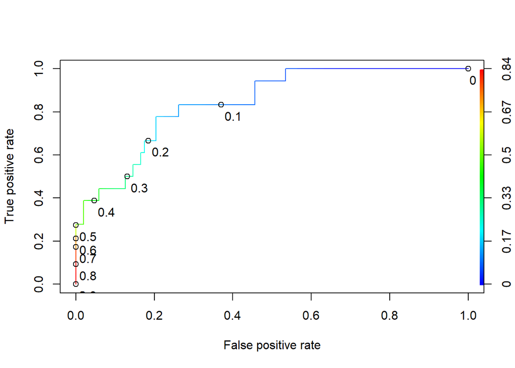

```r
# Plotting ROCR curve
condition.ROCRpred = prediction(condition.glm.predict, condition.test$SARS_COV2_Result)
condition.ROCRperf = performance(condition.ROCRpred, "tpr", "fpr")
plot(condition.ROCRperf, colorize=TRUE, print.cutoffs.at=seq(0,1,by=0.1), text.adj=c(-0.2,1.7))
```

Training plot. Probability of having SARS CoV-2 vs Predictor measure

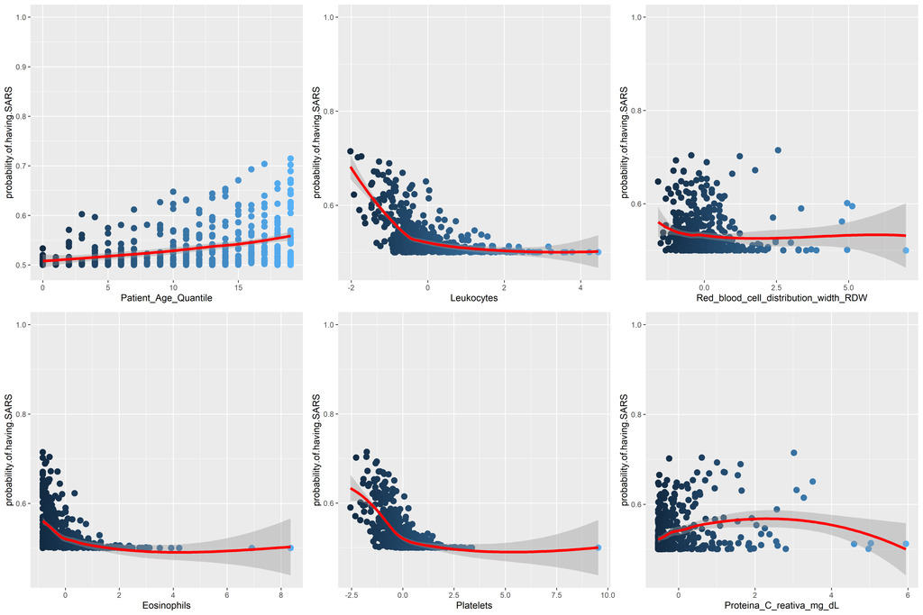

```r
grid.arrange(plot1, plot2, plot3, plot4, plot5, plot6, ncol=3 , nrow = 2)
```

## Condition dataset seperate investigation

Platelets *Monocytes* Hemoglobin *Red_blood_cells* Mean_platelet_volume *

Plotting linear fit, GAM fit, and Poly fit with degree 4 and compare them.

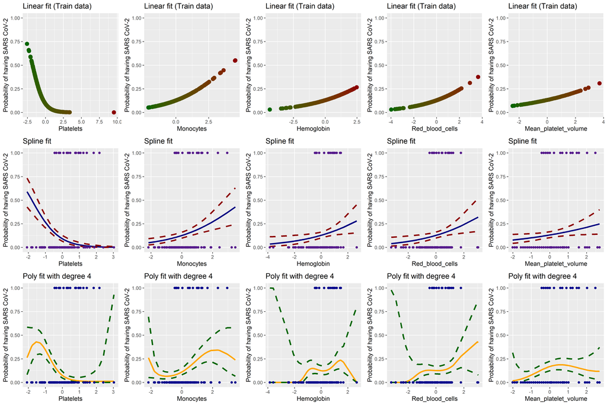

```r
grid.arrange(plotfun1, plotfun2, plotfun3, plotfun4, plotfun5,plotfun2.1, plotfun2.2, plotfun2.3, plotfun2.4, plotfun2.5,plotfun3.1, plotfun3.2, plotfun3.3, plotfun3.4, plotfun3.5, ncol=5 , nrow = 3)
```

## Dimension reduction with LASSO shrinkage

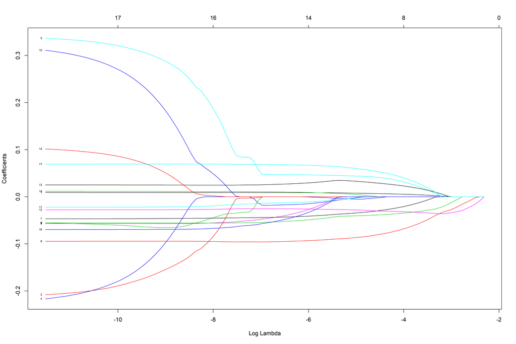

```r
#Shrinkage with LASSO (still working)
x=model.matrix(SARS_COV2_Result~.-1,data=condition.train)
y=condition.train$SARS_COV2_Result
fit.lasso=glmnet(x,y)
plot(fit.lasso,xvar="lambda",label=TRUE)
```

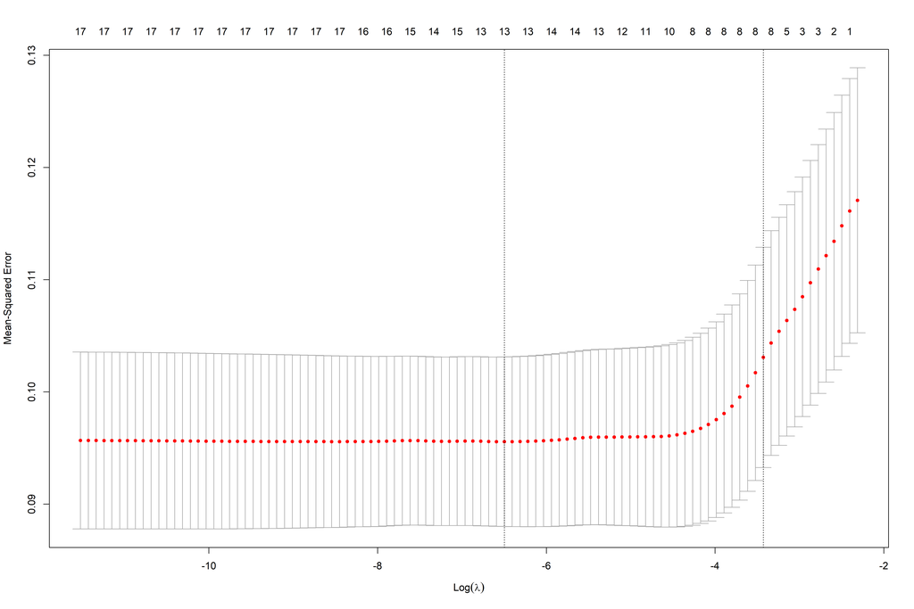

```r
cv.lasso=cv.glmnet(x,y)
plot(cv.lasso)
```

```r
coef(cv.lasso)
```

```
## 18 x 1 sparse Matrix of class "dgCMatrix"
##                                                           1
## (Intercept)                                     0.104460446
## Patient_Age_Quantile                            0.002922396
## Hematocrit                                      .
## Hemoglobin                                      .
## Mean_corpuscular_hemoglobin_MCH                 .
## Red_blood_cells                                 0.011326500
## Lymphocytes                                     .
## Basophils                                      -0.004189881
## Leukocytes                                     -0.044988118
## Eosinophils                                    -0.027495374
## Mean_corpuscular_volume_MCV                     .
## Red_blood_cell_distribution_width_RDW           .
## Platelets                                      -0.034792265
## Monocytes                                       0.012085940
## Mean_corpuscular_hemoglobin_concentration_MCHC  .
## Mean_platelet_volume                            .
## Neutrophils                                     .
## Proteina_C_reativa_mg_dL                        0.015192344
```

```r
dim(disease.train)
```

```
## [1] 1081   18
```

```r
set.seed(1)
train=sample(seq(nrow(condition.train)),nrow(condition.train) * 0.8,replace=FALSE)

lasso.tr=glmnet(x[train,],y[train])
#lasso.tr
pred=predict(lasso.tr,x[-train,])
dim(pred)
```

```
## [1]  97 100
```

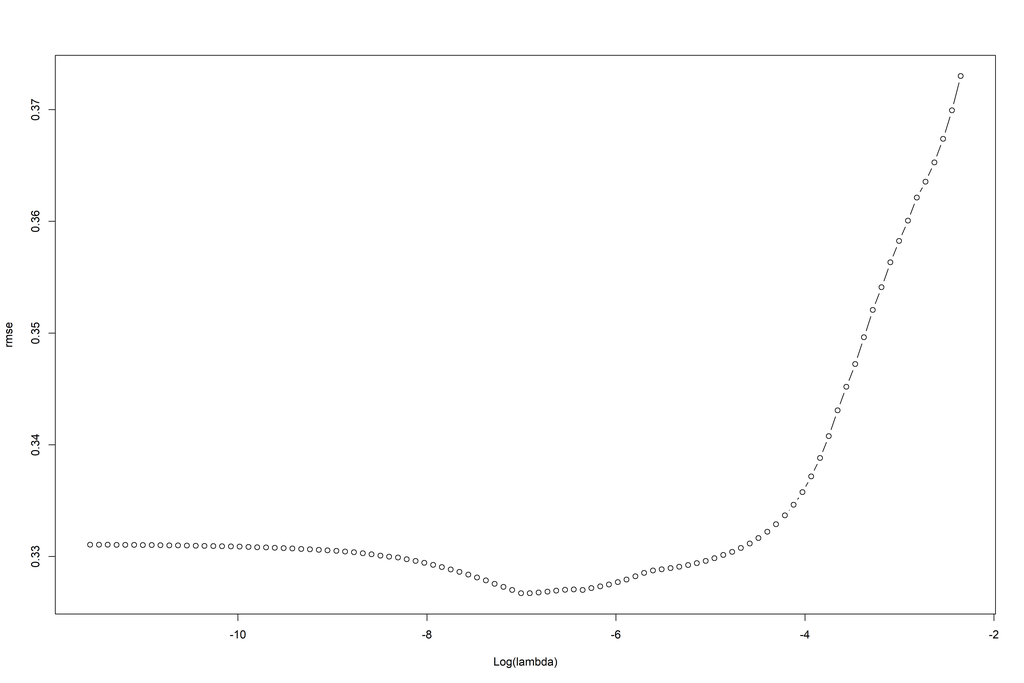

```r
rmse= sqrt(apply((y[-train]-pred)^2,2,mean))
plot(log(lasso.tr$lambda),rmse,type="b",xlab="Log(lambda)")
```

```r
lam.best=lasso.tr$lambda[order(rmse)[1]]
lam.best
```

```
## [1] 0.0009964067
```

```r
coef(lasso.tr,s=lam.best)
```

```
## 18 x 1 sparse Matrix of class "dgCMatrix"
##                                                           1
## (Intercept)                                     0.028122458
## Patient_Age_Quantile                            0.009464544
## Hematocrit                                     -0.031871886
## Hemoglobin                                     -0.001870118
## Mean_corpuscular_hemoglobin_MCH                 .
## Red_blood_cells                                 0.083264226
## Lymphocytes                                    -0.036074037
## Basophils                                      -0.042608504
## Leukocytes                                     -0.096462900
## Eosinophils                                    -0.052408399
## Mean_corpuscular_volume_MCV                     .
## Red_blood_cell_distribution_width_RDW          -0.012192444
## Platelets                                      -0.016298797
## Monocytes                                       0.026805871
## Mean_corpuscular_hemoglobin_concentration_MCHC  .
## Mean_platelet_volume                            0.018086096
## Neutrophils                                    -0.042721304
## Proteina_C_reativa_mg_dL                        0.061134804
```